# topic modeling

Mao Wang

2021/12/21

```r
library(tidyverse)
library(tidytext)
library(jiebaR) # 中文斷詞
library(tmcn) # install.packages("tmcn") # 簡體轉繁體
library(tictoc) # install.packages("tictoc")

# 模型會用到的套件
library(topicmodels) # install.packages("topicmodels") # 主題模型
library(ldatuning) # install.packages("ldatuning") # 協助判斷主題數
library(stm) # install.packages("stm") # 結構式主題模型
library(LDAvis) # install.packages("LDAvis")

# 使用Mac才需要執行（中文字體設定）
my_theme <- theme_bw() +
  theme(text = element_text(family = "STHeitiTC-Light"))
theme_set(my_theme)
```

## 1. 什麼是主題模型（topic modeling）

主題模型最早是由Blei、Ng與Jordan(2003)三位學者所提出，主題模型是假設主題與文件中的字詞（token）的出現符應**潛在狄利克雷分布（latent Dirichlet allocation, LDA）**，所以在某一主題下，所有字詞出現的機率加總為1。更具體得來講，這個演算法會將文件中的字詞分派（assign）到某一主題，再透過不斷迭代（iterative）的運算方式，調整文件中每個字詞分配到某主題的機率。

主題模型是植基詞袋模型的假設下來做分群（clustering），當然分群的方法不只主題模型，如K-平均（K-means）分群法也能作到分群，但K-平均只能將文件（document）分到單一主題。而主題模型的優勢就在於，其假設一份文件可能有多個主題，故在計算該文件之主題時，是以多個主題的機率（multinomial）去計算。

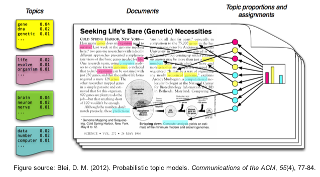

主題模型示意圖

接下來我們試試用審計部的新聞發布資料，看都提及些什麼主題。但首先我們要先將資料整理成文件-字詞矩陣（document-term matrix, DTM）

```r
# 讀入資料
load("data/nao.RData")
glimpse(data_all)
```

```
## Rows: 119
## Columns: 4
## $ title    <chr> "審計部試行金融區塊鏈函證服務平臺", "審計部2019年國際審計技術…
## $ date     <chr> "2019-04-01 ", "2019-03-11 ", "2019-03-01 ", "2019-03-01 ", "…
## $ link     <chr> "http://www.audit.gov.tw/p/405-1000-5375,c104.php?Lang=zh-tw"…
## $ fulltext <chr> "外部函證係審計機關重要審計程序及蒐集審計證據的方法之一，審計機關長期以來皆投入相當人力及時間辦理紙本詢證函作業，期提升審計品質及價值。民國(下同)105年財金資訊股份有限公司與台灣主要大型銀行共同成立金融區塊鏈研究暨應用發展委員會，歷時2年多探索與實作驗證區塊鏈技術，推出全球首創「金融區塊鏈函證服務平臺」。審計部為肆應上開金融科技新趨勢，自107年下半年主動研議導入，將於本(108)年4月1日正式試行，並與國內各會計師事務所同步。希各銀行及各被審核機關共同協助審計機關試行金融科技之電子化函證作業服務，共創無紙化及高效能的數位化審計函證新頁。", "審計…
```

```r
# 分詞引擎 # 如果要做好分析，請記得把斷詞引擎建好，有需要建入使用者自訂辭典的詞，請務必記得加入。
seg_engine <- worker(bylines = TRUE)
# new_user_word(worker = seg_engine, words = c("新加的詞1", "新加的詞2"))

# 停用詞辭典
zh_stopword <- stopwords::stopwords(language = "zh", source = "misc") %>%
  # 整理成tibble的格式
  tibble(word = .) %>%
  # 將簡體轉成繁體
  mutate(word = tmcn::toTrad(word)) %>%
  # 加上一些自訂的停用詞
  bind_rows(tibble(word = c("年", "月", "日", "民國", "與", "於", "並", "為", "項", "室", "審計部")))

# 中文斷詞
nao_token <- data_all %>%
  # 產生一個新的欄位叫id
  mutate(id = row_number()) %>%
  mutate(token = jiebaR::segment(fulltext, seg_engine)) %>%
  unnest(token)

# 建立dtm
nao_dtm <- nao_token %>%
  anti_join(zh_stopword, by = c("token" = "word")) %>%
  # 因為有了文件id，把title欄位刪除
  select(id, token) %>%
  # 把有數字的token都刪除
  filter(!str_detect(token, pattern = "\\d"),
         # 若只有一個字的token就刪除
         str_length(token) >= 2) %>%
  # 計算每個文件各token出現的次數（三個欄位：文件、詞彙、次數）
  count(id, token) %>%
  # 轉換成dtm
  tidytext::cast_dtm(document = id, term = token, value = n)

# 為什麼會有14個字元長的詞彙，檢查一下！
nao_token %>%
  mutate(chr_num = str_length(token)) %>%
  filter(chr_num >= 5) %>%
  pull(token)
```

```
##   [1] "Naohiro"        "Mouri"          "48.02"          "15.91"
##   [5] "https"          "policies"       "index"          "世界衛生組織"
##   [9] "https"          "policies"       "index"          "英國劍橋大學"
##  [13] "Centre"         "Studies"        "World"          "Cities"
##  [17] "2015-2025"      "271.7997"       "https"          "policies"
##  [21] "index"          "Alliance"       "Sustainable"    "Development"
##  [25] "Goals"          "INTOSAI"        "INTOSAI"        "insight"
##  [29] "foresight"      "https"          "policies"       "index"
##  [33] "https"          "policies"       "index"          "https"
##  [37] "policies"       "index"          "https"          "policies"
##  [41] "index"          "https"          "policies"       "index"
##  [45] "https"          "policies"       "index"          "376.00"
##  [49] "177.36"         "37.24"          "https"          "policies"
##  [53] "index"          "https"          "policies"       "index"
##  [57] "Ricardo"        "Rodriguez"      "Exploring"      "ESTRAT"
```

[output cut: 54 more lines]

```r
# 清理一下資料，把英文token也移除。
nao_dtm <- nao_token %>%
  anti_join(zh_stopword, by = c("token" = "word")) %>%
  filter(!str_detect(token, pattern = "\\d"),
         # 若只有一個字的token就刪除
         str_length(token) >= 2,
         # 把有英文的token都刪除（但如果英文對你的研究重要，請不要刪除。）
         !str_detect(token, pattern = "[a-zA-Z]")) %>%
  select(id, token) %>%
  count(id, token) %>%
  tidytext::cast_dtm(document = id, term = token, value = n)

nao_dtm
```

```
## <<DocumentTermMatrix (documents: 115, terms: 3470)>>
## Non-/sparse entries: 10298/388752
## Sparsity           : 97%
## Maximal term length: 6
## Weighting          : term frequency (tf)
```

完成了前置作業，接下來就是把`nao_dtm`放入跑主題模型的函式內。

## 2. LDA

統計模型處理是`R`的強項，所以跑模型時，其實比一般清理資料要簡單很多，只需要把基本的參數設定好，結果就出來了！但參數設定牽涉到對於模型的理解，反而需要有比較穩固的統計基礎才能夠真的得心應手。

```r
# 將nao_dtm放入LDA函式。
nao_lda <- topicmodels::LDA(nao_dtm,
                            # 主題數
                            k = 6,
                            # 估測方法
                            method = "Gibbs",
                            # 為了要讓結果可以重現，另外設定seed。
                            control = list(seed = 5691))

# 將lda的token結果轉回data frame的格式
(nao_topics_token <- tidytext::tidy(nao_lda, matrix = "beta")) # 可以看到每個term都有相對應在各主題的beta值。
```

```
## # A tibble: 20,820 × 3
##    topic term        beta
##    <int> <chr>      <dbl>
##  1     1 上開   0.0000315
##  2     2 上開   0.0000519
##  3     3 上開   0.0000467
##  4     4 上開   0.0000438
##  5     5 上開   0.00137
##  6     6 上開   0.0000263
##  7     1 下半年 0.0000315
##  8     2 下半年 0.0000519
##  9     3 下半年 0.0000467
## 10     4 下半年 0.0000438
## # … with 20,810 more rows
```

```r
# ?tidytext::lda_tidiers

# 驗證一下剛剛說的，每個主題的字詞機率加總為1
nao_topics_token %>%
  # 以主題分群
  group_by(topic) %>%
  # 各群機率加總
  summarize(prob = sum(beta))
```

```
## # A tibble: 6 × 2
##   topic  prob
##   <int> <dbl>
## 1     1     1
## 2     2     1
## 3     3     1
## 4     4     1
## 5     5     1
## 6     6     1
```

主題模型的結果很容易就跑出來，但是要注意，模型結果只是幫我們分群，實際上**研究者必須依照分群內的字詞自行為各主題命名**。接著我們試著用圖像的方式呈現這些數據。

```r
# 將每個主題機率最高的20個字列出
(nao_plot <- nao_topics_token %>%
  group_by(topic) %>%
  top_n(15, wt = beta) %>%
  ungroup() %>%
  arrange(topic, -beta) %>%
  mutate(order = row_number())
)
```

```
## # A tibble: 95 × 4
##    topic term     beta order
##    <int> <chr>   <dbl> <int>
##  1     1 社會   0.0227     1
##  2     1 同仁   0.0189     2
##  3     1 愛心   0.0189     3
##  4     1 關懷   0.0180     4
##  5     1 服務   0.0158     5
##  6     1 身心   0.0145     6
##  7     1 中心   0.0120     7
##  8     1 障礙者 0.0120     8
##  9     1 代表   0.0111     9
## 10     1 參訪   0.0111    10
## # … with 85 more rows
```

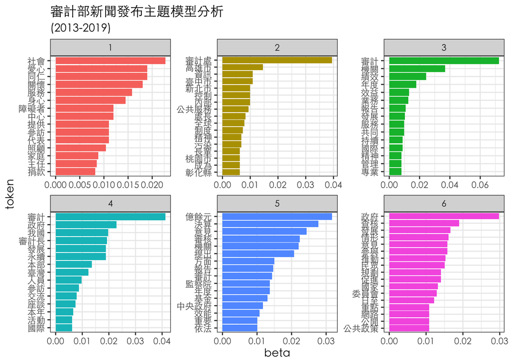

```r
# 畫圖將主題資料呈現出來
(p_token <- ggplot(nao_plot,
                   aes(reorder_within(term, by = beta, within = topic),
                     y = beta,
                     fill = factor(topic))) +
  geom_col(show.legend = FALSE) +
  scale_x_reordered() +
  facet_wrap(~ topic, scales = "free") +
  coord_flip() +
  labs(x = "token", y = "beta", title = "審計部新聞發布主題模型分析",
       subtitle = "(2013-2019)")
)
```

除了看各主題裡面有哪些字詞外，也可以看看談論各主題的文件呈現怎麼樣的分配。

```r
# 將lda的document結果轉回data frame的格式
(nao_topics_doc <- tidytext::tidy(nao_lda, matrix = "gamma"))
```

```
## # A tibble: 690 × 3
##    document topic  gamma
##    <chr>    <int>  <dbl>
##  1 1            1 0.127
##  2 2            1 0.0895
##  3 3            1 0.165
##  4 4            1 0.181
##  5 5            1 0.0727
##  6 6            1 0.0860
##  7 7            1 0.0591
##  8 8            1 0.0766
##  9 9            1 0.0767
## 10 10           1 0.0746
## # … with 680 more rows
```

```r
# topicmodels::posterior(object = nao_lda) %>% .$topics

# 驗證一下剛剛說的，每個文件的主題機率加總為1
nao_topics_doc %>%
  # 因為document欄位現在是文字型，排序會跟數值型不同。
  # mutate(document = as.numeric(document)) %>%
  # 以文件分群
  group_by(document) %>%
  # 每一文件之主題機率加總為1
  summarize(prob = sum(gamma))
```

```
## # A tibble: 115 × 2
##    document  prob
##    <chr>    <dbl>
##  1 1            1
##  2 10           1
##  3 100          1
##  4 101          1
##  5 102          1
##  6 103          1
##  7 104          1
##  8 105          1
##  9 106          1
## 10 107          1
## # … with 105 more rows
```

```r
# 將data frame排序來看，第一百份文件的情況
nao_topics_doc %>%
  arrange(document) %>%
  filter(document == 100)
```

```
## # A tibble: 6 × 3
##   document topic  gamma
##   <chr>    <int>  <dbl>
## 1 100          1 0.0642
## 2 100          2 0.0538
## 3 100          3 0.0903
## 4 100          4 0.648
## 5 100          5 0.0903
## 6 100          6 0.0538
```

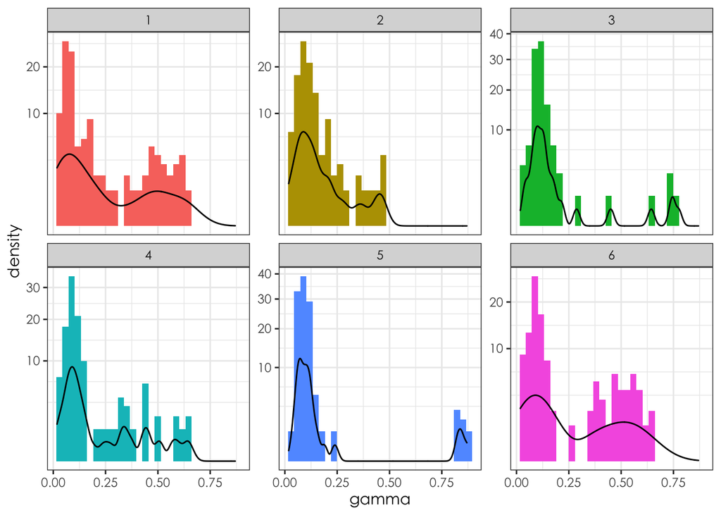

```r
# 畫出各主題的文件分布情況
(p_doc <- ggplot(nao_topics_doc, aes(x = gamma)) +
  geom_histogram(aes(fill = factor(topic)), show.legend = FALSE) +
  # 平滑版的geom_histogram
  geom_density(alpha = 0.4, show.legend = FALSE) +
  scale_y_sqrt() +
  facet_wrap(~ topic, scales = "free_y")
)
```

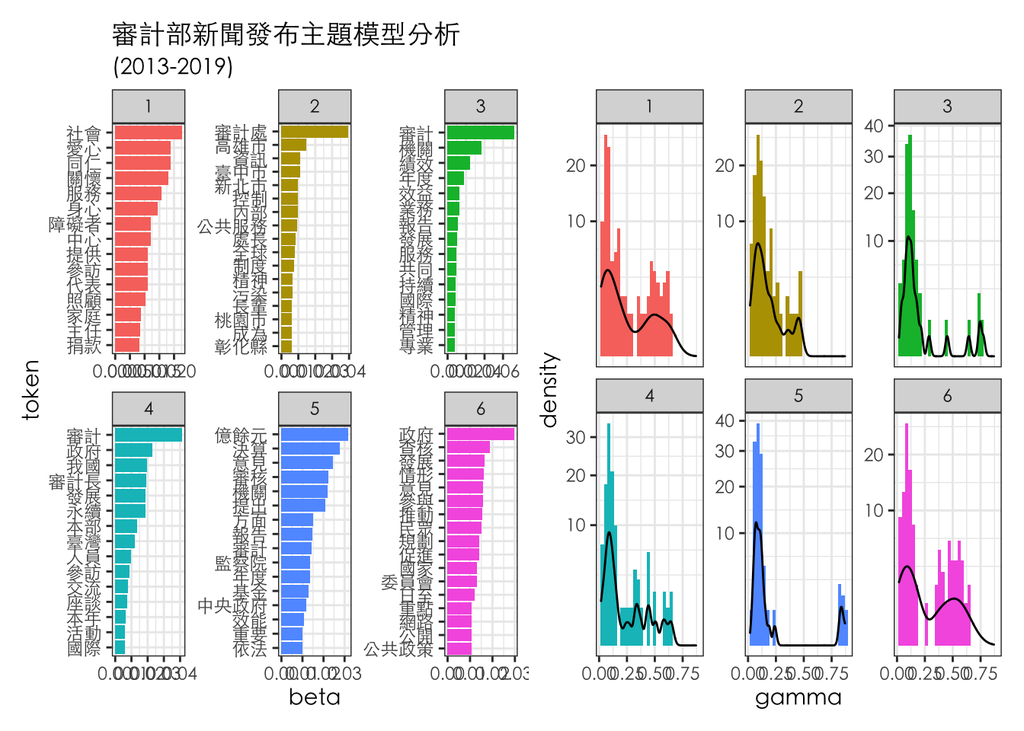

```r
library(patchwork) # install.packages("patchwork)
p_token + p_doc
```

從上面兩個圖可以得知，除了各主題實際上談論的內容外，也可以看出各文件（審計部新聞發布）在各主題的分布情況。以主題五為例，呈現比較兩極的結果，代表談論主題五的文件，有很大比重是只談主題五；而談論其他主題的文件，則很少為單一主題。

## 2.1 如何決定主題數？

因為主題模型是屬於**非監督式**的機器學習（unsupervised machine learning）的一種方法，所以不像監督式機器學習有確切的依變數可供我們驗證，因此無法用像混淆矩陣（confusion matrix）的方式來計算正確性。但還是有其他輔助的指標可供我們參考，以下將主要介紹複雜度（perplexity，或稱不確定度）指標，來協助我們決定主題數。

```r
# 取出log-likelihood
topicmodels::logLik(nao_lda)
```

```
## 'log Lik.' -93178.83 (df=20820)
```

```r
# 取出複雜度（perplexity）：當複雜度越低，代表每個主題間區隔得越清楚，也是我們最希望得到的結果。
topicmodels::perplexity(object = nao_lda, newdata = nao_dtm)
```

```
## [1] 714.8582
```

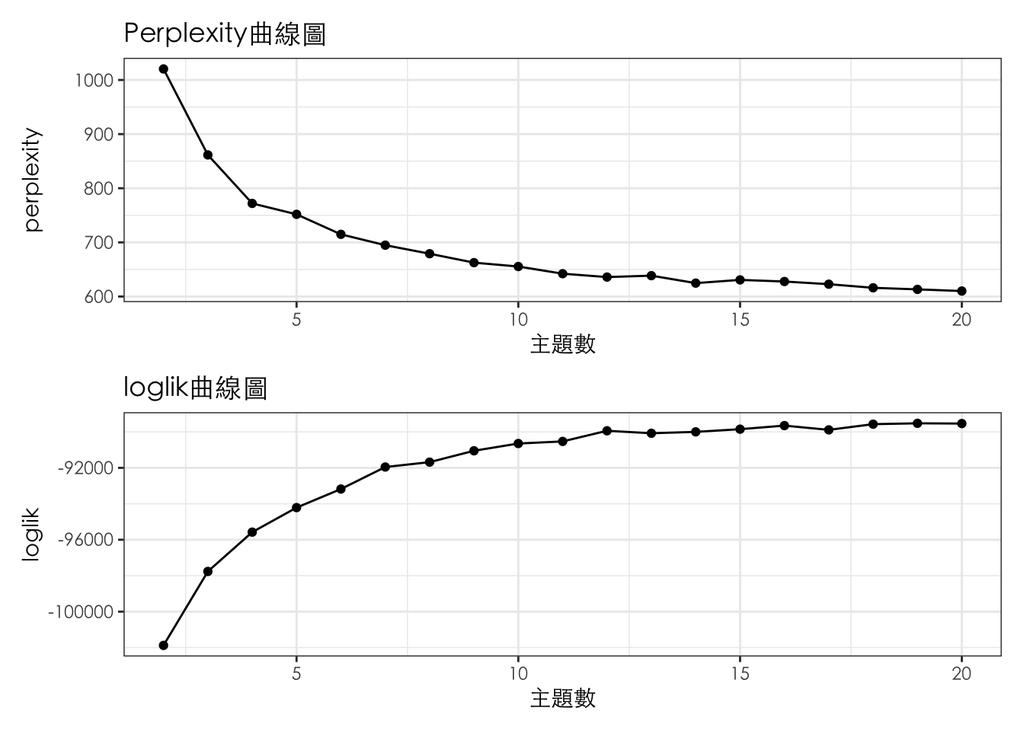

```r
# 將主題數2:20放入函式中去跑，當然也可以用for loop的方式寫
nao_lda_list <- map(.x = 2:20, ~topicmodels::LDA(nao_dtm,
                            # 主題數
                            k = .x,
                            # 估測方法
                            method = "Gibbs",
                            # 為了要讓結果可以重現，另外設定seed。
                            control = list(seed = 5691)))

# 將上述的資訊整理在tibble中
k_data <- tibble(
  k = 2:(length(nao_lda_list) + 1),
  loglik = map_dbl(nao_lda_list, topicmodels::logLik),
  perplexity = map_dbl(nao_lda_list,
                       topicmodels::perplexity, newdata = nao_dtm))

# 畫出複雜度曲線，選擇適合的主題數
perplexity_plot <- ggplot(k_data, aes(x = k, y = perplexity)) +
  geom_line() +
  geom_point() +
  labs(x= "主題數", title = "Perplexity曲線圖")

# 畫出loglik曲線，選擇適合的主題數
loglik_plot <- ggplot(k_data, aes(x = k, y = loglik)) +
  geom_line() +
  geom_point() +
  labs(x= "主題數", title = "loglik曲線圖")

perplexity_plot + loglik_plot + plot_layout(ncol = 1)
```

上面的結果看起來應該是6-7是一個比較合理的主題數。但除了這種算法外，也有研究者開發出其他指標，並且我們可以直接使用套件來計算。

```r
# 決定主題數
tic()
result <- ldatuning::FindTopicsNumber(
  nao_dtm,
  topics = seq(from = 2, to = 20, by = 1),
  metrics = c("Griffiths2004", "CaoJuan2009", "Arun2010", "Deveaud2014"),
  method = "Gibbs",
  control = list(seed = 5691),
  mc.cores = 2L, # 用雙CPU運算
  verbose = TRUE)
```

```
## fit models... done.
## calculate metrics:
##   Griffiths2004... done.
##   CaoJuan2009... done.
##   Arun2010... done.
##   Deveaud2014... done.
```

```r
toc()
```

```
## 28.597 sec elapsed
```

```r
beepr::beep(2)

result
```

```
##    topics Griffiths2004 CaoJuan2009 Arun2010 Deveaud2014
## 1      20     -90290.25  0.08560554 111.6618    1.100441
## 2      19     -90190.55  0.08492350 113.1896    1.126132
## 3      18     -90118.29  0.08334960 113.7437    1.165817
## 4      17     -90377.94  0.08700993 119.3846    1.186635
## 5      16     -90238.70  0.08154881 116.8979    1.233877
## 6      15     -90275.58  0.08092976 119.6167    1.268727
## 7      14     -90400.73  0.07972397 118.9734    1.313935
## 8      13     -90337.80  0.08186962 123.0262    1.353132
## 9      12     -90767.61  0.08522572 122.9898    1.410633
## 10     11     -90799.83  0.08613930 129.1877    1.440841
## 11     10     -91093.32  0.08366168 128.6252    1.495272
## 12      9     -91787.55  0.08972241 132.7182    1.550061
## 13      8     -92097.32  0.10191963 135.0770    1.592836
## 14      7     -92366.17  0.09640639 140.4819    1.657160
## 15      6     -93462.31  0.11404142 147.7088    1.670238
## 16      5     -94542.88  0.12500773 156.6899    1.721179
## 17      4     -95936.17  0.13605271 163.7851    1.808131
## 18      3     -98021.50  0.11818097 175.7296    1.898519
## 19      2    -102021.90  0.21635792 196.8890    1.861159
```

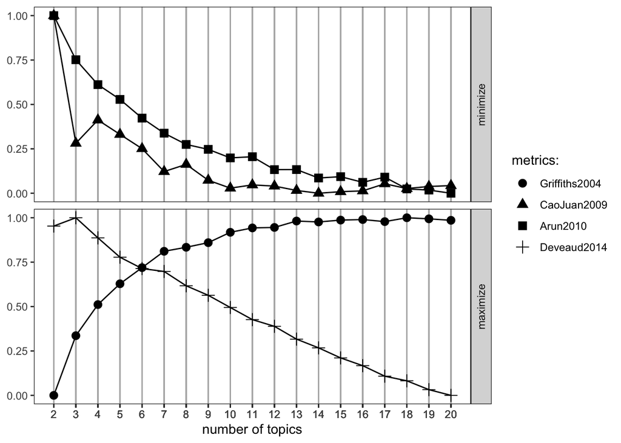

```r
# 畫圖看大概幾個主題比較適合
ldatuning::FindTopicsNumber_plot(result)
```

## 3. stm

除了LDA的主題模型，其實也有學者發展出不同的主題模型，我們接著要介紹的主題模型叫做結構式主題模型（structural topic model）。與前面的LDA差異僅在於加入了文件的後設資料（metadata），如作者、文件發布日等，可以使主題模型更準確。

```r
# 讀入資料
trump <- readr::read_csv("data/trump_twitter_archive.csv") %>%
  mutate(text = str_conv(text, encoding = "UTF-8")) %>%
  mutate(month = lubridate::mdy_hms(created_at) %>%
           lubridate::month()) %>%
  # 把無法正確分析的日期，用下一筆觀察值補上
  fill(month, .direction = "up")
# trump %>% filter(is.na(month))
glimpse(trump)
```

```
## Rows: 1,230
## Columns: 8
## $ source         <chr> "Twitter for iPhone", "Twitter for iPhone", "Twitter fo…
## $ text           <chr> "Such an easy way to avoid Tariffs? Make or produce you…
## $ created_at     <chr> "05-11-2019 13:55:14", "05-10-2019 21:13:28", "05-10-20…
## $ retweet_count  <dbl> 29478, 15623, 14150, 17197, 16267, 14155, 19338, 13931,…
## $ favorite_count <chr> "133624", "60055", "71964", "85559", "73539", "56359", …
## $ is_retweet     <chr> "FALSE", "FALSE", "FALSE", "FALSE", "FALSE", "FALSE", "…
## $ id_str         <dbl> 1.12721e+18, 1.12696e+18, 1.12693e+18, 1.12693e+18, 1.1…
## $ month          <dbl> 5, 5, 5, 5, 5, 5, 5, 5, 5, 5, 5, 5, 5, 5, 5, 5, 5, 5, 5…
```

```r
# 資料清理
processed <- textProcessor(documents = trump$text,
                           metadata = trump)
```

```
## Building corpus...
## Converting to Lower Case...
## Removing punctuation...
## Removing stopwords...
## Removing numbers...
## Stemming...
## Creating Output...
```

```r
names(processed)
```

```
## [1] "documents"    "vocab"        "meta"         "docs.removed"
```

```r
# 可以檢視各式什麼內容
map(processed, head)
```

```
## $documents
## $documents$`1`
##      [,1] [,2] [,3] [,4] [,5] [,6] [,7] [,8] [,9] [,10] [,11]
## [1,]  202  904 1260 2095 2375 2630 2631 3023 3252  3489  3581
## [2,]    1    1    2    1    1    1    1    1    1     1     1
##
## $documents$`2`
##      [,1] [,2] [,3] [,4] [,5] [,6] [,7] [,8] [,9] [,10] [,11] [,12] [,13] [,14]
## [1,]   38  150  422  722  749  801 1029 1186 1418  1460  1994  2061  2184  2276
## [2,]    1    1    1    1    1    1    1    1    1     1     1     1     3     1
##      [,15] [,16] [,17] [,18] [,19]
## [1,]  2377  2995  3119  3446  3478
## [2,]     1     1     3     1     1
##
## $documents$`3`
##      [,1] [,2] [,3] [,4] [,5] [,6] [,7] [,8] [,9] [,10] [,11] [,12] [,13] [,14]
## [1,]  460  609  774 1202 1334 1750 2130 2151 2290  2775  2807  3137  3252  3450
## [2,]    1    1    1    2    1    1    2    1    1     1     1     1     1     1
##      [,15]
## [1,]  3624
## [2,]     1
##
## $documents$`4`
##      [,1] [,2] [,3] [,4] [,5] [,6] [,7] [,8] [,9] [,10] [,11] [,12] [,13] [,14]
## [1,]  393  460  602  617  638  647  722 1371 2377  2460  2592  2762  2769  3137
## [2,]    1    1    1    2    1    1    1    1    1     1     1     2     1     1
##      [,15] [,16] [,17] [,18] [,19]
## [1,]  3143  3180  3357  3422  3450
## [2,]     1     1     1     1     1
##
## $documents$`5`
##      [,1] [,2] [,3] [,4] [,5] [,6] [,7] [,8] [,9] [,10] [,11] [,12] [,13] [,14]
## [1,]  285  288  390  827 1066 1232 1288 2338 2681  2767  2793  3017  3074  3137
## [2,]    2    1    1    1    1    2    2    1    1     2     1     1     1     1
##      [,15] [,16] [,17] [,18] [,19]
## [1,]  3287  3331  3543  3624  3649
## [2,]     1     1     1     1     1
##
## $documents$`6`
##      [,1] [,2] [,3] [,4] [,5] [,6] [,7] [,8] [,9] [,10] [,11] [,12] [,13] [,14]
```

[output cut: 20 more lines]

```
## 2      Military spouses share an admirable legacy of unwavering devotion to their loved ones in uniform and to the cause of freedom. On Military Spouse Day we honor our Nation?�s military spouses and express our deep appreciation for all that they do! https://t.co/B3NrKc698y
## 3                                                                                  ....into the future will continue. In the meantime the United States has imposed Tariffs on China which may or may not be removed depending on what happens with respect to future negotiations!
## 4 Over the course of the past two days the United States and China have held candid and constructive conversations on the status of the trade relationship between both countries. The relationship between President Xi and myself remains a very strong one and conversations....
## 5                                                                       Great Republican vote today on Disaster Relief Bill. We will now work out a bipartisan solution that gets relief for our great States and Farmers. Thank you to all. Get me a Bill that I can quickly sign!
## 6                                                                  ?�We have been engaged in an unfair relationship with China for a long time. They have reneged on the commitments they made to the WTO particularly around intellectual property.??Carly Fiorina @MariaBartiromo
##            created_at retweet_count favorite_count is_retweet      id_str month
## 1 05-11-2019 13:55:14         29478         133624      FALSE 1.12721e+18     5
## 2 05-10-2019 21:13:28         15623          60055      FALSE 1.12696e+18     5
## 3 05-10-2019 19:14:04         14150          71964      FALSE 1.12693e+18     5
## 4 05-10-2019 19:14:04         17197          85559      FALSE 1.12693e+18     5
## 5 05-10-2019 17:57:00         16267          73539      FALSE 1.12691e+18     5
## 6 05-10-2019 13:39:11         14155          56359      FALSE 1.12684e+18     5
##
## $docs.removed
## integer(0)
```

```r
# 轉換成stm分析的格式（注意：會自動再清理資料一次！）
out <- prepDocuments(documents = processed$documents,
                     vocab = processed$vocab,
                     meta = processed$meta)
```

```
## Removing 2051 of 3856 terms (2051 of 19873 tokens) due to frequency
## Removing 66 Documents with No Words
## Your corpus now has 1164 documents, 1805 terms and 17822 tokens.
```

```r
# out是經過stm套件轉換過的內容，之後要使用請都使用out內的資料才不會出錯
names(out)
```

```
## [1] "documents"      "vocab"          "meta"           "words.removed"
## [5] "docs.removed"   "tokens.removed" "wordcounts"
```

```r
# 這邊做或不做沒關係，只是為了讓後面的code看起來簡單點
docs <- out$documents
vocab <- out$vocab
meta <- out$meta

# 建立stm模型
trump_stm <- stm(documents = docs, vocab = vocab,
              K = 10, data = meta,
              # prevalence就是拿來當成是covariate的欄位資料，請用formula的方式寫
              prevalence = ~ month,
              # 預設是500次迭代計算，課堂演示只用100次試試
              max.em.its = 100, seed = 5691,
              init.type = "Spectral")
```

[output not shown]

[output cut: 542 more lines]

[output not shown]

stm是一個很完整的主題模型分析套件，幾乎所有的主題模型該做的任務，都可以在這個套件內完成，但缺點是這個套件對於中文資料的支援比較差，建議大家若要使用這個套件，請先以英文資料優先。接著來看看分析出來有哪些主題，還有哪些內容。

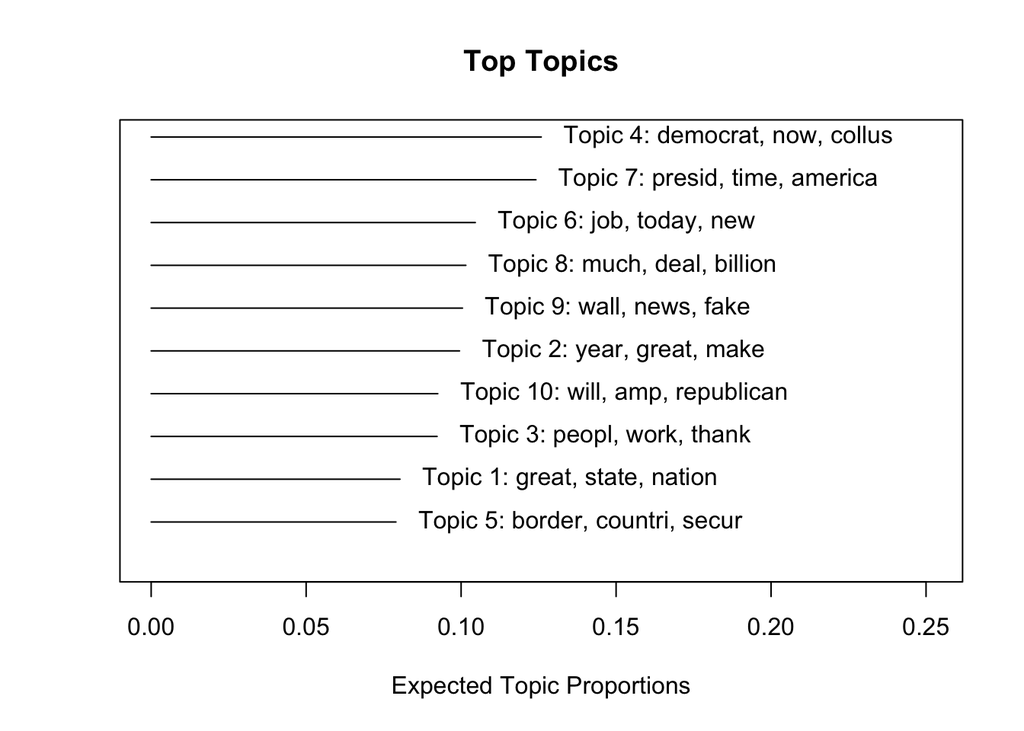

```r
# 畫出最高比重的主題
plot(trump_stm)
```

```r
# 查看主題內的字詞
labelTopics(model = trump_stm, topics = c(7, 6, 3))
```

```
## Topic 7 Top Words:
##       Highest Prob: presid, time, america, amp, histori, economi, hunt
##       FREX: low, isi, joe, histori, puerto, rico, berni
##       Lift: biden, elizabeth, envi, httpstcohccnfzxfn, hurrican, husband, instead
##       Score: presid, hunt, histori, witch, rate, time, session
## Topic 6 Top Words:
##       Highest Prob: job, today, new, great, total, just, fbi
##       FREX: lie, book, spoke, whitehous, cohen, prime, lisa
##       Lift: affect, afternoon, ballabon, barra, behalf, bibi, blame
##       Score: loser, today, lie, honor, book, spoke, fight
## Topic 3 Top Words:
##       Highest Prob: peopl, work, thank, day, hous, big, american
##       FREX: thank, white, hous, truli, love, within, tiger
##       Lift: african, bust, dumb, food, heather, opportun, snow
##       Score: thank, peopl, work, hous, day, catastroph, love
```

```r
# 保險的方式還是看看原文寫了什麼，找出主題六、七，各取兩篇document來看
findThoughts(model = trump_stm,
             texts = meta$text,
             n = 2, topics = 7:6)
```

```
##
##  Topic 7:
##       The Kentucky Derby decision was not a good one. It was a rough &amp; tumble race on a wet and sloppy track actually a beautiful thing to watch. Only in these days of political correctness could such an overturn occur. The best horse did NOT win the Kentucky Derby - not even close!
##      The Kentuky Derby decision was not a good one. It was a rough and tumble race on a wet and sloppy track actually a beautiful thing to watch. Only in these days of political correctness could such an overturn occur. The best horse did NOT win the Kentucky Derby - not even close!
##  Topic 6:
##       Virtually everything failed lawyer Michael Cohen said in his sworn testimony last week is totally contradicted in his just released manuscript for a book about me. It?�s a total new love letter to ?�Trump??and the pols must now use it rather than his lies for sentence reduction!
##      Today it was my great honor to welcome Prime Minister @Netanyahu of Israel back to the @WhiteHouse where I signed a Presidential Proclamation recognizing Israel?�s sovereignty over the Golan Heights. Read more: https://t.co/yAAyR2Hxe4 https://t.co/gWp6nwRwsY
```

## 3.1 如何決定主題數？

因為stm也是主題模型，所以還是**必須由研究者選擇 K（主題數）**，而`stm::searchK`可以幫助我們判斷多少主題才是比較適合了。

```r
tictoc::tic()
findingk <- stm::searchK(documents = out$documents,
                         vocab = out$vocab,
                         K = c(5, 7, 9, 10, 12, 15),
                         data = meta,
                         prevalence = ~ month,
                         max.em.its = 50,
                         verbose = TRUE)
```

[output not shown]

[output cut: 1709 more lines]

[output not shown]

```r
tictoc::toc() # 在我的電腦約需2分鐘
```

```
## 122.898 sec elapsed
```

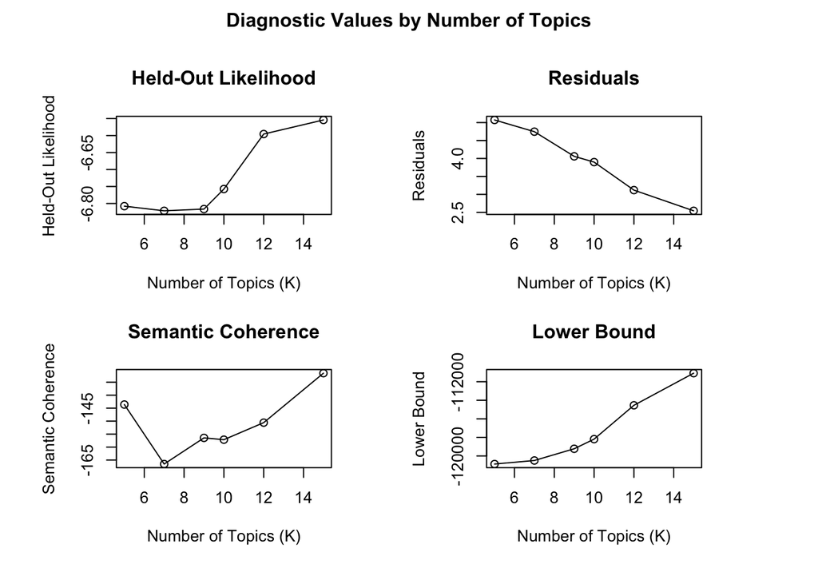

```r
plot(findingk)
```

```r
# held-out高、residual低、semantic coherence高
```

從結果來看，15個主題可能是目前最適合的，但因為我們只試做到15個主題，實際上在測試需要多少主題時，會以10, 20, 30, 40或更多先去找可能的區間。因為stm與做這樣的模擬需要較多的運算資源，所以當文字資料量大時，會需要花很多時間才能跑出結果。

對於實際操作尚有不理解的同學，可以看`tidytext`這個套件的作者之一Julia Silge的操作影片。 [Topic modeling with R and tidy data principles](https://www.youtube.com/watch?v=evTuL-RcRpc)

## bonus (LDAvis)

如果對於主題模型視覺化有興趣的同學，可以參考另一個套件叫`LDAvis`，語法可參考這個 [連結](https://ldavis.cpsievert.me/reviews/reviews.html)，實際成品可參考這個 [連結](https://ldavis.cpsievert.me/reviews/vis/#topic=7&lambda=0.6&term=)

### 其他補充

因為主題模型是一個尚在發展的方法，換句話說，也還有許多改善的空間，目前除了常見的unsupervised的方法外，最近也發展出semisupervised的方法，如`keyATM`[連結](https://keyatm.github.io/keyATM/)。另外，也有更多學者開始重視主題模型的驗證（validation）議題，可以使用`oolong`[連結](https://cran.r-project.org/web/packages/oolong/index.html)，有興趣的同學開始自行參閱。